# Wk2 Naive Bayes using European Banks Churn Data

## Naive Bayes

This project used **churn_df.csv** dataset, from [Kaggle](https://www.kaggle.com/datasets/barelydedicated/bank-customer-churn-modeling). It represents bank churn data from a bank in Europe. “Churn” is a term that refers to customers leaving and taking their business elsewhere.

Topics of focus include:

- Relevant import statements
- Stratification during data splitting
- Fitting a Naive Bayes model
- Evaluating the model on test data

### Objectives

This project's objective is to test a Naive Bayes model that uses banking data to predict whether a customer will churn.If we can **predict customers who are likely to churn, we can take measures to retain them** before they do.These measures could be promotions, discounts, or other incentives to boost customer satisfaction and, therefore, retention.

Our target variable is `Exited`, which is a Boolean value that indicates whether or not a customer left the bank (0 = did not leave, 1 = did leave).For each customer, our model will predict whether they should have a **0 or 1** in the `Exited` column.

We will use `GaussianNB` classifier.This implementation assumes that all variables are *continuous* *and* that they have a *Gaussian* (i.e., normal) distribution. Our data doesn't perfectly adhere to these assumptions, but a Gaussian model may still yield usable results, even with imperfect data.

```python
import numpy as np
import pandas as pd
import matplotlib.pyplot as plt

from sklearn.model_selection import train_test_split
from sklearn.naive_bayes import GaussianNB

from sklearn.metrics import recall_score, precision_score, f1_score, accuracy_score
from sklearn.metrics import confusion_matrix, ConfusionMatrixDisplay
```

```python
churn_df=pd.read_csv('churn_df.csv')
churn_df.head()
```

|  | CreditScore | Age | Tenure | Balance | NumOfProducts | HasCrCard | IsActiveMember | EstimatedSalary | Exited | Loyalty | Geography_Germany | Geography_Spain |
| --- | --- | --- | --- | --- | --- | --- | --- | --- | --- | --- | --- | --- |
| 0 | 619 | 42 | 2 | 0.00 | 1 | 1 | 1 | 101348.88 | 1 | 0.047619 | 0 | 0 |
| 1 | 608 | 41 | 1 | 83807.86 | 1 | 0 | 1 | 112542.58 | 0 | 0.024390 | 0 | 1 |
| 2 | 502 | 42 | 8 | 159660.80 | 3 | 1 | 0 | 113931.57 | 1 | 0.190476 | 0 | 0 |
| 3 | 699 | 39 | 1 | 0.00 | 2 | 0 | 0 | 93826.63 | 0 | 0.025641 | 0 | 0 |
| 4 | 850 | 43 | 2 | 125510.82 | 1 | 1 | 1 | 79084.10 | 0 | 0.046512 | 0 | 1 |

```python
# check class balance
churn_df['Exited'].value_counts()
```

```
0    7963
1    2037
Name: Exited, dtype: int64
```

The class is split roughly 80:20, which means approximately 20% of the people in this dataset churned. This is an **unbalanced** dateset, but not extreme.  
We'll proceed without altering the class balance of our target variabl, as performing class balancing would change terms in a way that would no longer relect the real-world distribution of the data.

```python
# As discussed in 'Wk2 Feature Engineering using European Banks Churn Data', and generated `Loyalty` feature.
churn_df = churn_df.drop(['Tenure', 'Age'], axis=1)
churn_df.head()
```

|  | CreditScore | Balance | NumOfProducts | HasCrCard | IsActiveMember | EstimatedSalary | Exited | Loyalty | Geography_Germany | Geography_Spain |
| --- | --- | --- | --- | --- | --- | --- | --- | --- | --- | --- |
| 0 | 619 | 0.00 | 1 | 1 | 1 | 101348.88 | 1 | 0.047619 | 0 | 0 |
| 1 | 608 | 83807.86 | 1 | 0 | 1 | 112542.58 | 0 | 0.024390 | 0 | 1 |
| 2 | 502 | 159660.80 | 3 | 1 | 0 | 113931.57 | 1 | 0.190476 | 0 | 0 |
| 3 | 699 | 0.00 | 2 | 0 | 0 | 93826.63 | 0 | 0.025641 | 0 | 0 |
| 4 | 850 | 125510.82 | 1 | 1 | 1 | 79084.10 | 0 | 0.046512 | 0 | 1 |

```python
# Define the y variable
y=churn_df['Exited']

# Define the x vairbales
X=churn_df.copy()
X=X.drop('Exited',axis=1)

# Split into train and test sets
X_train, X_test, y_train, y_test = train_test_split(X, y, test_size=0.25, \
                                                    stratify=y, random_state=42)
```

### Modelling

#### 1. Unscaled Data

Just as with linear and logistic regression, our modeling process will begin with *fitting our model to the training data*, and then using the model to make predictions on the test data.

```python
# Fit the model
gnb = GaussianNB()
gnb.fit(X_train, y_train)

# Get the predictions on test data
y_preds = gnb.predict(X_test)
```

Let's check how the model performs using the evaluation metrics imported

```python
print('Accuracy:', '%.3f' % accuracy_score(y_test, y_preds))
print('Precision:', '%.3f' % precision_score(y_test, y_preds))
print('Recall:', '%.3f' % recall_score(y_test, y_preds))
print('F1 Score:', '%.3f' % f1_score(y_test, y_preds))
```

```
Accuracy: 0.796
Precision: 0.000
Recall: 0.000
F1 Score: 0.000
```

There are two ways for the model to have a precision of zero. The first is if the **numerator is zero**, which would mean that our model didn’t predict any true positives.

The second is if the **denominator is also zero**, which would mean that our model didn’t predict any positives at all. Dividing by zero results in an undefined value, but scikit-learn will return a value of zero in this case.

If we call `np.unique()` on the model's predictions and it doesn't return an array containing `[0, 1]`, we'll know it's not predicticting any churned customers.

```python
# Check unique values in predictions
np.unique(y_preds)
```

```
array([0], dtype=int64)
```

This confirms that the model predicted 0 (not churned) for every sample in the test data.

To investigate, use `describe()` to inspect the X data.

```python
# Get descriptive stats for data
X.describe()
```

|  | CreditScore | Balance | NumOfProducts | HasCrCard | IsActiveMember | EstimatedSalary | Loyalty | Geography_Germany | Geography_Spain |
| --- | --- | --- | --- | --- | --- | --- | --- | --- | --- |
| count | 10000.000000 | 10000.000000 | 10000.000000 | 10000.00000 | 10000.000000 | 10000.000000 | 10000.000000 | 10000.000000 | 10000.000000 |
| mean | 650.528800 | 76485.889288 | 1.530200 | 0.70550 | 0.515100 | 100090.239881 | 0.137936 | 0.250900 | 0.247700 |
| std | 96.653299 | 62397.405202 | 0.581654 | 0.45584 | 0.499797 | 57510.492818 | 0.089506 | 0.433553 | 0.431698 |
| min | 350.000000 | 0.000000 | 1.000000 | 0.00000 | 0.000000 | 11.580000 | 0.000000 | 0.000000 | 0.000000 |
| 25% | 584.000000 | 0.000000 | 1.000000 | 0.00000 | 0.000000 | 51002.110000 | 0.064516 | 0.000000 | 0.000000 |
| 50% | 652.000000 | 97198.540000 | 1.000000 | 1.00000 | 1.000000 | 100193.915000 | 0.129032 | 0.000000 | 0.000000 |
| 75% | 718.000000 | 127644.240000 | 2.000000 | 1.00000 | 1.000000 | 149388.247500 | 0.200000 | 1.000000 | 0.000000 |
| max | 850.000000 | 250898.090000 | 4.000000 | 1.00000 | 1.000000 | 199992.480000 | 0.555556 | 1.000000 | 1.000000 |

As the table showed, the `Loyalty` variable we created is on a vastly different scale than some of the other variables we have, such as `Balance` or `EstimatedSalary`. The maximum value of `Loyalty` is 0.56, while the maximum for `Balance` is over 250,000—almost six orders of magnitude greater!

#### 2. Scaled data

Naive Bayes does not require data scaling. However, sometimes packages and libraries need to make assumptions and approximations in their calculations. We're already breaking some of these assumptions by using the `GaussianNB` classifier on this dataset, and it may not be helping that some of our predictor variables are on very different scales. In general, scaling might not improve the model, but it probably won't make it worse.

`MinMaxScaler`,imported from the `sklearn.preprocessing` module, to normalizes each column so every value falls in the range of [0, 1]. The column's maximum value would scale to **1**, and its minimum value would scale to 0. Everything else would fall somewhere between. This is the formula:

$${x_{scaled}} = \frac{x - x_{min}}{x_{max} - x_{min}}$$

To use a scaler, must fit it to the training data, and transform both the training data *and* the test data using that same scaler.

```python
from sklearn.preprocessing import MinMaxScaler

# instantiate the scaler
scaler = MinMaxScaler()

# Fit the scaler to the training data
scaler.fit(X_train)

# Scale the training data
X_train = scaler.transform(X_train)

# Scale the test data
X_test = scaler.transform(X_test)
```

Re-fit the model, with new scaled data

```python
# Fit the model
gnb_scaled = GaussianNB()
gnb_scaled.fit(X_train, y_train)

scaled_preds=gnb_scaled.predict(X_test)
```

```python
print('Accuracy:', '%.3f' % accuracy_score(y_test, scaled_preds))
print('Precision:', '%.3f' % precision_score(y_test,scaled_preds))
print('Recall:', '%.3f' % recall_score(y_test, scaled_preds))
print('F1 Score:', '%.3f' % f1_score(y_test, scaled_preds))
```

```
Accuracy: 0.806
Precision: 0.544
Recall: 0.303
F1 Score: 0.389
```

## Evaluation

Create a confusion matrix, which is a graphic that shows models true and false positives, and true and false negatives.

```python
def conf_matrix_plot(model,x_data,y_data):
    '''
    Accepts as argument model object, X data (test or validate), and y data (test or validate).
    Return a plot of confusion matrix for predictions on y data.
    '''

    model_pred=model.predict(x_data)
    cm = confusion_matrix(y_data, model_pred, labels=model.classes_)
    disp = ConfusionMatrixDisplay(confusion_matrix=cm,
                                 display_labels=model.classes_
                                 )
    disp.plot(values_format='')# `values_format=''` suppresses scientific notation
    plt.show()
```

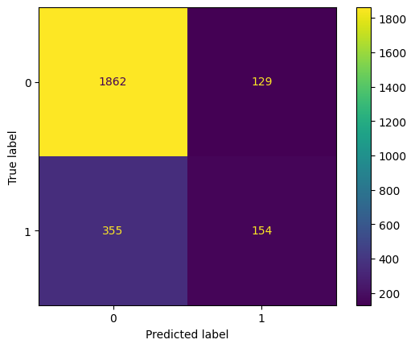

```python
conf_matrix_plot(gnb_scaled, X_test, y_test)
```

As the matrix showed, the model misses a lot of customers who will churn. In other words, there are **355 false negatives**. This is why our recall score is only 0.303.